# HAR Exercise Prediction

## Summary

For this project we will use the HAR dataset (http://groupware.les.inf.puc-rio.br/har) to attempt to predict how well an exercise is performed based an various measures taken by captors placed on the subjects body.

## Data Clean Up and Preparation

```r
har_raw <- read.csv("https://d396qusza40orc.cloudfront.net/predmachlearn/pml-training.csv")

prepare_data <- function(data) {
  non_na_index <- which(colSums(is.na(data)) == 0)
  df <- data[,non_na_index]
  non_div0_index <- which(colSums(df == "#DIV/0!") == 0)
  df <- df[,non_div0_index]
  df[,-(1:7)]
}

har <- prepare_data(har_raw)
```

We sub-divide the data into a training and a probing set. The probing set will be used to perform cross validation.

```r
inTrain <- createDataPartition(y = har$classe, p = 0.75, list = FALSE)

training <- har[inTrain,]
probing <- har[-inTrain,]
```

## Exploratory Analysis

We plot a couple of charts to get a feel for whether there are any predictors that can be used to determine whether the exercise is done well

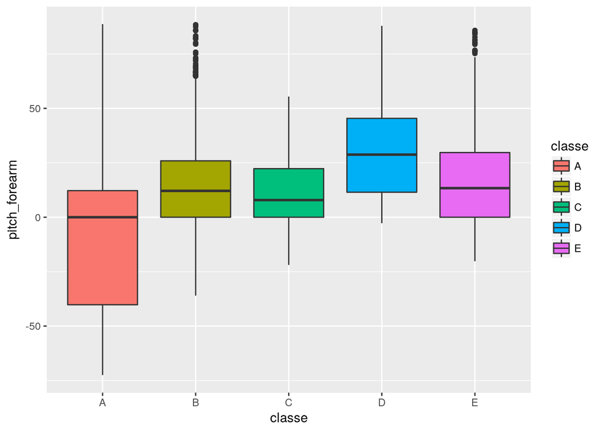

```r
ggplot(training, aes(x = classe, y = pitch_forearm, fill = classe)) + geom_boxplot()
```

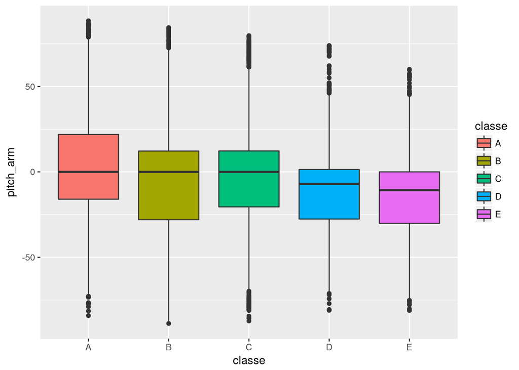

```r
ggplot(training, aes(x = classe, y = pitch_arm, fill = classe)) + geom_boxplot()
```

## Model Selction

We fit 3 different models on the training set (descision tree, random forest and linear discriminant analysis). Each model uses all the variables retained in training set to try to predict the value of the “classe”" variable. We will select the model with the best accuracy.

```r
modelRpart <- train(classe ~ ., training, method = "rpart")
modelRF <- train(classe ~ ., training, method = "rf")
modelLDA <- train(classe ~ ., training, method = "lda")
```

We test each model on the probing set. The most accurate model seems to be the one using random forest with an accuracy of 99.33%. This is therefore the model we are going to use.

```r
cmRpart <- confusionMatrix(predict(modelRpart, probing), probing$classe)
cmRpart$overall[["Accuracy"]]
```

```
## [1] 0.4869494
```

```r
cmRF <- confusionMatrix(predict(modelRF, probing), probing$classe)
cmRF$overall[["Accuracy"]]
```

```
## [1] 0.9932708
```

```r
cmLDA <- confusionMatrix(predict(modelLDA, probing), probing$classe)
cmLDA$overall[["Accuracy"]]
```

```
## [1] 0.7063622
```

The out of sample error for that model is 0.67%

```r
cm <- confusionMatrix(predict(modelRF, probing), probing$classe)
error <- 1 - cm$overall[["Accuracy"]]
error
```

```
## [1] 0.006729201
```